# Homework 3: GAM and NN

Vijay Penmetsa

There are four questions (30 total points) in this assignment. The minimum increment is 1 point. Please type in your answers directly in the R Markdown file. After completion, **successfully** knitr it as an html file. Submit **both** the html file and the R Markdown file via Canvas. Please name the R Markdown file in the following format: LastName_FirstName_HW3.Rmd, e.g. Zhao_Zifeng_HW3.Rmd.

## Credit Balance Dataset [30 points]

The credit balance dataset contains information about 400 individuals’ credit usage and other personal information. The data is stored in `Credit.csv`. It contains 8 variables, `Income`, `Limit`, `Rating`, `Cards`, `Age`, `Education`, `Student`, and `Balance`. We would like to build several statistical models to predict `Balance` (i.e. credit usage) of a person with given personal information. The data description is as follows.

- `Income`: Income in $1,000’s
- `Limit`: Credit limit
- `Rating`: Credit rating
- `Cards`: Number of credit cards
- `Age`: Age in years
- `Education`: Education in years
- `Student`: A factor with levels No and Yes indicating whether the individual is a student
- `Balance`: Average credit card balance in $.

### **Q1 [4 points]** Data Partition

**Q1(a) [2 points]** Let’s correctly read in the data in `Credit.csv` and name it as `total_data`.

```r
## Write code solution to Q1(a) here
total_data <- read.csv("./Credit.csv", header = TRUE, stringsAsFactors = TRUE)
```

**Q1(b) [2 points]** Let’s partition the data in `total_data` into training **(80%)** and test data **(20%)** and store them as `R` objects `train_data` and `test_data` respectively. Use random seed **`set.seed(7)`**!

```r
## Write code solution to Q1(b) here
set.seed(7)
total_obs <- dim(total_data)[1]

train_indices <- sample(1:total_obs, 0.8 * total_obs)

train_data <- total_data[train_indices, ]
test_data <- total_data[-train_indices, ]
```

### **Q2 [8 points]** Linear Regression and GAM

**Q2(a) [3 points]** Fit a linear regression model of the **original scale** `Balance` w.r.t. all 7 predictors using the **training data**, name it `lm_full`.

```r
## Write code solution to Q2(a) here
lm_full <- lm(Balance ~ Income+Limit+Rating+Cards+Age+Education+Student,
              data = train_data)
summary(lm_full)
```

```
##
## Call:
## lm(formula = Balance ~ Income + Limit + Rating + Cards + Age +
##     Education + Student, data = train_data)
##
## Residuals:
##      Min       1Q   Median       3Q      Max
## -188.326  -79.655   -5.796   56.124  311.180
##
## Coefficients:
##               Estimate Std. Error t value Pr(>|t|)
## (Intercept) -466.71223   37.56296 -12.425  < 2e-16 ***
## Income        -7.67677    0.26236 -29.260  < 2e-16 ***
## Limit          0.22455    0.03648   6.155 2.31e-09 ***
## Rating         0.58621    0.54530   1.075    0.283
## Cards         22.82347    4.98795   4.576 6.86e-06 ***
## Age           -0.37604    0.32471  -1.158    0.248
## Education     -1.87516    1.80173  -1.041    0.299
## StudentYes   418.76975   20.36558  20.563  < 2e-16 ***
## ---
## Signif. codes:  0 '***' 0.001 '**' 0.01 '*' 0.05 '.' 0.1 ' ' 1
##
## Residual standard error: 98.39 on 312 degrees of freedom
## Multiple R-squared:  0.954,  Adjusted R-squared:  0.9529
## F-statistic: 923.7 on 7 and 312 DF,  p-value: < 2.2e-16
```

**Q2(b) [5 points]** Fit a GAM of the **original scale** `Balance` w.r.t. all 7 predictors using the **training data**, name it `gam_full`. Let’s use splines with **df=4** for all 6 numerical predictors, which include `Income`, `Limit`, `Rating`, `Cards`, `Age` and `Education`.

```r
library(gam)
## Write code solution to Q2(b) here
gam_full <- gam(Balance ~
                  s(Income, df = 4)
                + s(Limit, df = 4)
                + s(Rating, df = 4)
                + s(Cards, df = 4)
                + s(Age, df = 4)
                + s(Education, df = 4)
                + Student,
                data = train_data)
```

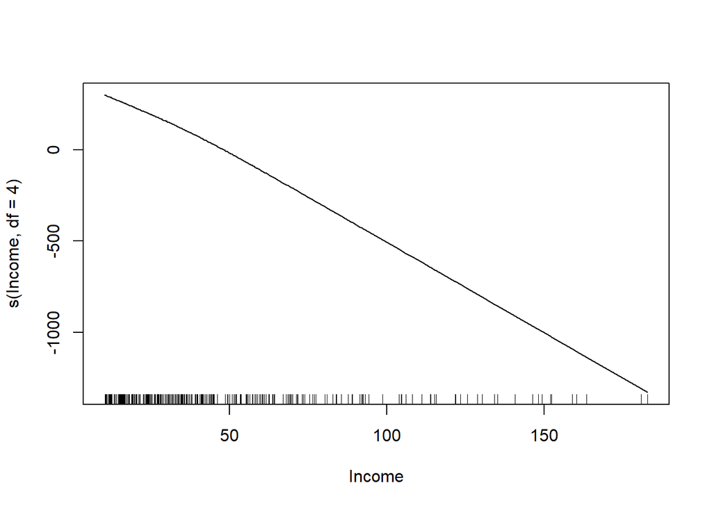

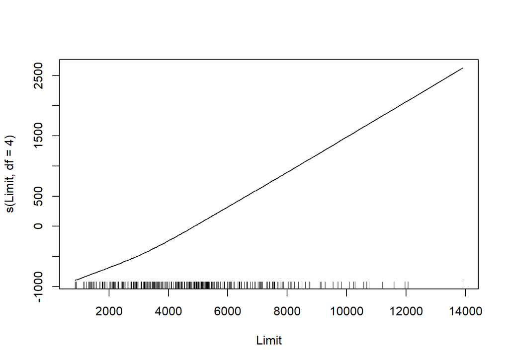

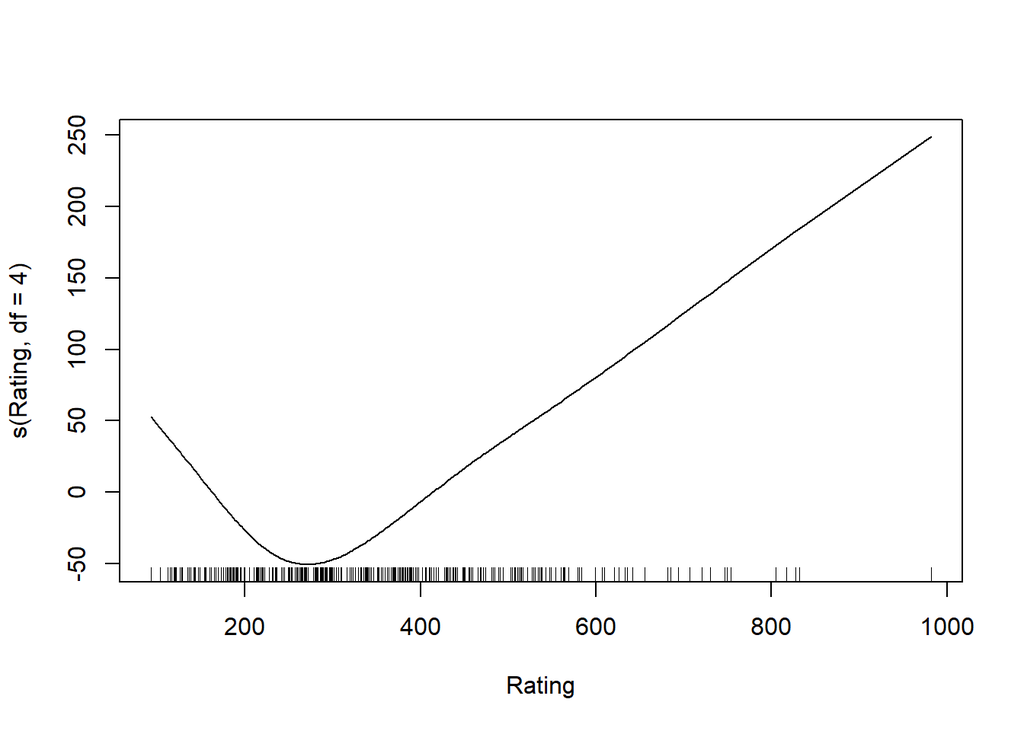

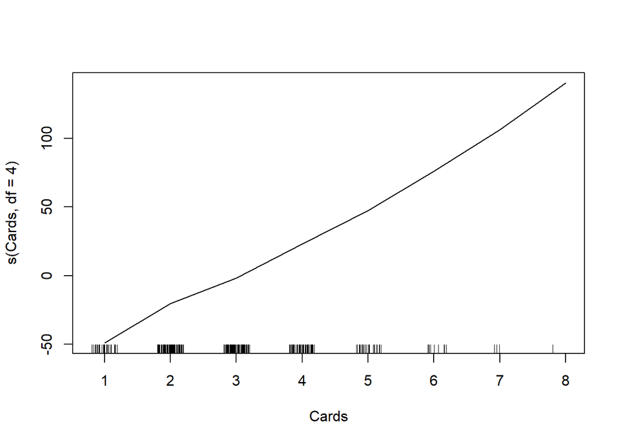

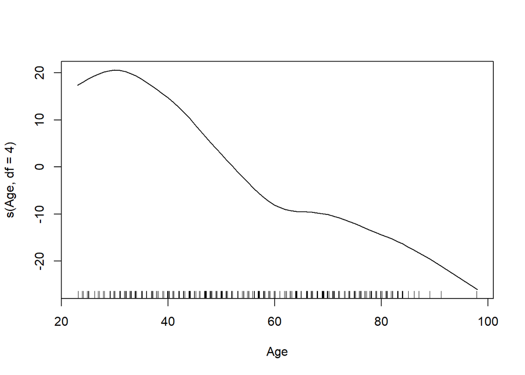

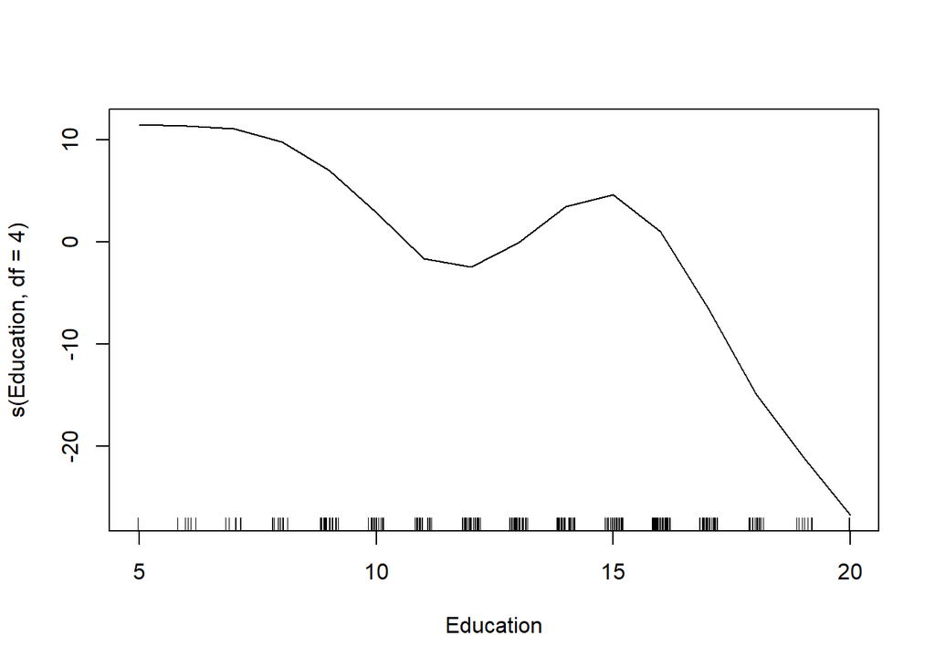

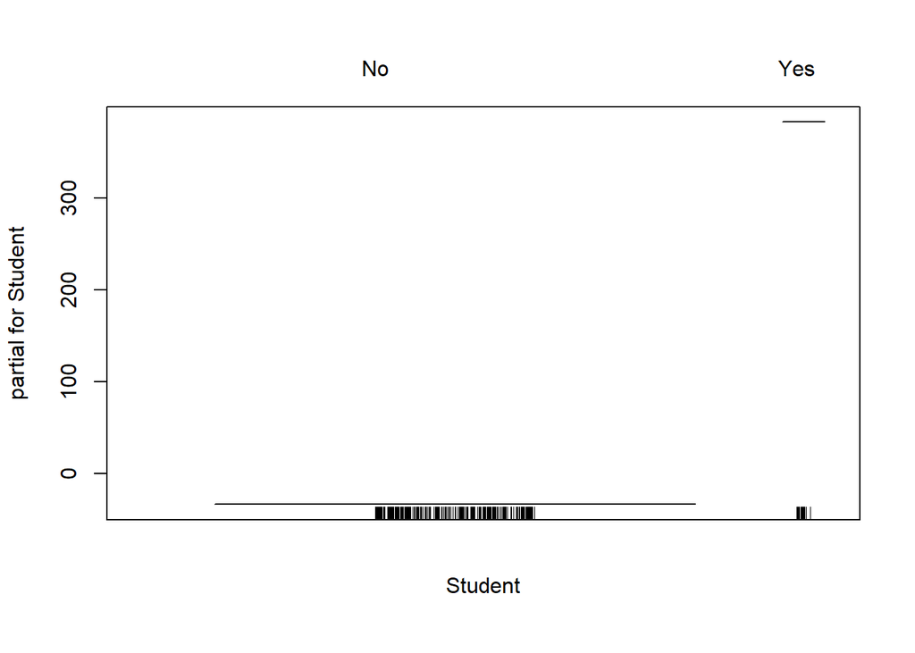

```r
plot(gam_full)
```

### **Q3 [10 points]** Neural Networks

Fit an NN of **standardized** `Balance` w.r.t. all 7 predictors using the **training data**, name it `nn_full`. For the architecture of NN, let’s use two hidden layers with 4 hidden units in the first layer and 2 hidden units in the second layer.

**Q3(a) [2 points]** Let’s generate the **training dataset** that are needed for the estimation of NN using the function `model.matrix()` and store it in `x_train_nn`. In addition, use the `scale()` function to standardize the predictors by centering with mean and scaling with sd.

```r
## Write code solution to Q3(a) here
x_train_nn <- model.matrix(~Income+Limit+Rating+Cards+Age+Education+Student,
                           data = train_data)[, -1]

x_mean <- apply(x_train_nn, 2, mean)
x_sd <- apply(x_train_nn, 2, sd)

x_train_nn <- scale(x_train_nn, center = x_mean, scale = x_sd)
```

**Q3(b) [2 points]** Let’s further standardize the dependent variable `Balance` by dividing its maximum value. In addition, combine the standardized `Balance` with the standardized predictors `x_train_nn` generated in Q3(a).

```r
## Write code solution to Q3(b) here
y_max <- max(train_data$Balance)
x_train_nn <- cbind.data.frame(train_data$Balance/y_max, x_train_nn)
colnames(x_train_nn)[1] <- "Balance"
```

**Q3(c) [2 points]** Let’s generate the **test dataset** that are needed for the out-of-sample prediction evaluation of NN using the function `model.matrix` and store it in `x_test_nn`. Use the `scale()` function to standardize the predictors by centering with mean and scaling with sd as in Q3(a).

```r
## Write code solution to Q3(c) here
x_test_nn <- model.matrix(~Income+Limit+Rating+Cards+Age+Education+Student,
                           data = test_data)[, -1]

x_test_nn <- scale(x_test_nn, center = x_mean, scale = x_sd)
```

**Q3(d) [4 points]** Let’s fit an NN that has two hidden layers with 4 hidden units in the first layer and 2 hidden units in the second layer. Make sure to use random seed **`set.seed(7)`**!

```r
## Write code solution to Q3(d) here
library(neuralnet)
set.seed(7)
nn_full <- neuralnet(Balance~Income+Limit+Rating+Cards+Age+Education+StudentYes,
                 data=x_train_nn, hidden=c(4,2))
```

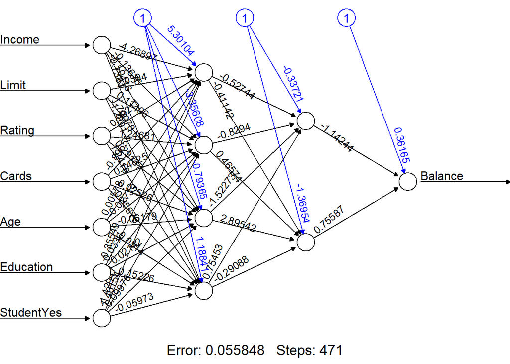

```r
plot(nn_full, rep = "best")
```

### **Q4 [8 points]** Model Evaluation (Prediction)

**Q4(a) [4 points]** Use `lm_full`, `gam_full` and `nn_full` to generate predictions for `Balance` on the test data and store the prediction in `lm_pred`, `gam_pred` and `nn_pred` respectively. Note that for prediction based on `nn_full`, make sure to transform the prediction of **standardized scale** `Balance` back to the **original scale**.

```r
## Write code solution to Q4(a) here
lm_full_pred <- predict(lm_full, newdata=test_data)
gam_full_pred <- predict(gam_full, newdata=test_data)
nn_full_pred <- predict(nn_full, newdata=x_test_nn, type='response')[,1]*y_max
```

**Q4(b) [2 points]** Use the `R` package `forecast` to evaluate the prediction performance of `lm_full`, `gam_full` and `nn_full`. What are the MAE for `lm_full`, `gam_full` and `nn_full`? (Note that MPE and MAPE may be undefined as some persons have `Balance`=0.)

```r
library(forecast)
## Write code solution to Q4(b) here
accuracy(lm_full_pred, test_data$Balance)
```

```
##                 ME     RMSE      MAE MPE MAPE
## Test set -4.077176 101.7312 84.22484 NaN  Inf
```

```r
accuracy(gam_full_pred, test_data$Balance)
```

```
##                  ME     RMSE      MAE MPE MAPE
## Test set -0.4461055 70.19443 51.80754 NaN  Inf
```

```r
accuracy(nn_full_pred, test_data$Balance)
```

```
##                 ME     RMSE      MAE MPE MAPE
## Test set 0.4645821 37.62021 29.34589 NaN  Inf
```

Answer:  
lm_full MAE = 84.22484  
gam_full MAE = 51.80754  
nn_full MAE = 29.34589

**Q4(c) [2 points]** Which statistical model do you prefer, `lm_full` or `gam_full` or `nn_full`? Give reasons.

Answer:  
I prefer nn_full because of the significantly low MAE compared to gam_full and lm_full.